# IIT Public Safety Off-Campus Ride Service Optimization

Sanaz Kazemzadehazad, Illinois Institute of Technology[^1]

Spring 2025 SoReMo Fellowship Project Final Technical Report

[Back to journal](https://soremo.library.iit.edu)

# Abstract

The Mies Campus of Illinois Institute of Technology (IIT) is in the high-crime area of Bronzeville in Chicago, with a crime rate significantly higher than the national average. According to anecdotal sources, students report feeling embarrassed due to long waits for off-campus ride services and a lack of equitable resource allocation. This concern is particularly pressing for students who stay late on campus for classes, studying, or project deadlines and must resort to alternative means of transportation such as ride-hailing platforms (e.g., Lyft and Uber) or walking, which can be, respectively, financially burdensome and risky in high-crime areas. Limited pickup locations, an inequitable first-come, first-served system, and uneven fleet distribution exacerbate these issues, leaving many students feeling unsafe.

Despite the efforts and efficiency of the Department of Public Safety (DPS), there is room for improvement in its performance regarding student ride services, as many students face significant challenges during late-night commutes when they are unable to use DPS services. Therefore, IIT should take on the ethical responsibility of addressing the challenges faced by students commuting to the Mies campus.

This project aims to identify the gaps in the DPS ride services by conducting a qualitative study and interviews to gain a deeper understanding of students’ experiences and opinions. After extracting the sub-indicators in each challenge category, relevant solutions and equity indexes are provided to help the university in the development of a fair and effective system for allocating public safety resources.

# Introduction

Providing safety for students is one of the key responsibilities of each university. The Mies campus of IIT is located in the Bronzeville area, boasting an annual individual crime rate of 1.2 per 1,000 persons (https://www, n.d.b). IIT is committed to fostering a safe and inclusive environment for its students, faculty, and staff with the support of the DPS. DPS plays a pivotal role in ensuring campus safety through services such as crime prevention, emergency response, on-campus escorts, crime reporting facilitation, collaboration with law enforcement, and student ride services. However, the DPS ride services are utilizing fewer DPS resources now compared to previous years (the fleet is decreased from 4 to 1, and the pickup locations are decreased to two).

## DPS Policies

DPS policies are published on their websites, which consist of policies for off-campus escort services as shown below (Longwell-Grice 2018).

- The Off-Campus Escorts begin from a central pickup point on Mies Campus and are offered on a first-come, first-serve basis and operate between 7 p.m.–3 a.m. from:
- Galvin Library: Sunday–Thursday
- The southwest entrance of Hermann Hall: Friday–Saturday
- The escort vehicle is normally expected to make two round trips per hour, depending upon how many passenger destinations are requested and traffic conditions. The exact time of arrival and departure, however, cannot be guaranteed.
- Requesting a Public Safety Escort
- There is no need to call Public Safety to request this type of escort. However, if a wait is more than 30 minutes, passengers are encouraged to call the Public Safety escort phone number to check the status. Otherwise, the escort number, 312.808.6310, is only for on-campus to on-campus escort requests.
- ID Requirement
- Illinois Tech identification must be shown in order to receive security escorts.
- Passengers can request to be dropped off at any point on the route.
- The escort driver is also allowed to deviate up to one block from the route to accommodate passengers but must inform the public safety watch commander before doing so.
- If no passengers are traveling to the westernmost or easternmost point of the route, the escort driver is authorized to take a shorter route back to campus in order to save time before the next pick-up, again with notification to the watch commander.
- During peak times, an additional vehicle may be assigned to the escort route, with one escort vehicle covering the western half of the route and the other vehicle covering the eastern half of the route.

## Escort Route

[figure not shown]

Figure 1a — Routes and areas of coverage by DPS ride services

[figure not shown]

Figure 1b — Google Earth view of origin and destinations

# Background

Many universities offer shuttle services and off-campus escort programs to enhance student safety, especially during late hours. These programs vary widely in their operational models, safety protocols, funding, and usage. Universities increasingly rely on campus shuttle programs—commonly known as “Safe Ride” services—to enhance student safety during night-time and high-risk hours. Research demonstrates that these programs not only deter crime but also prevent impaired driving, while ongoing evaluation and technological innovation ensure continuous improvement.

A foundational study by Longwell-Grice and Siever (Longwell-Grice 2018) provides direct evidence that Safe Ride programs lead to a measurable reduction in student victimization and neighborhood crime. By offering students a reliable, university-sponsored transportation option, campuses create safer environments and reduce exposure to risk.

Building on this, Sarkar, Andreas, and de Faria (Sarkar 2005) examine how Safe Ride programs specifically address the challenge of impaired driving. Their research found that nearly half of surveyed users would have driven while drunk if the shuttle service were unavailable, highlighting the program’s crucial role in public health and safety.

These findings are further supported by comprehensive literature reviews. The Traffic Injury Research Foundation ((TIRF) 2017) synthesize evidence across many studies, concluding that effective safe ride and shuttle programs are typically associated with reductions in alcohol-related crashes, DUI arrests, and fatalities. Importantly, they identify key success factors: high campus awareness, accessibility, affordability, and a strong perception of safety among users. These factors must be central to any campus shuttle initiative.

Best practices in program operation and design are detailed by policy-focused sources. The Transportation Research Board ((TRB) 2008) asserts that student safety, schedule reliability, and quality of service are the “core mission” of campus transit systems. Their synthesis notes that leading universities frequently integrate new technology and foster partnerships to bolster both the safety and efficiency of their shuttles.

To ensure these programs maintain high standards, ongoing evaluation and adaptation are critical. A TRB case study ((TRB) 2021) describes how one large public university developed a robust safety program for its shuttle system, emphasizing the importance of specialized driver training (especially for student drivers) and ongoing education tailored to campus-specific conditions. These steps help address frequent driver turnover and dynamic campus travel patterns.

Real-world program evaluation and redesign are showcased in the University of North Dakota Campus Shuttle Study by Scott et al. (Scott 2011). Through systematic data collection and user feedback, the study identified opportunities for service redesign—such as adding dedicated night shuttles—to improve both efficiency and safety. This underscores the value of evidence-based adjustments to meet evolving student needs.

To understand how each university addresses campus transportation safety needs, the University of Texas at Austin (UT Austin), the University of Pennsylvania (Penn), and the University of Illinois at Urbana-Champaign (UIUC) are examined in detail, where each employs different strategies for shuttles (fixed-route or on-demand buses) and escorts (walking or riding services), reflecting their unique campus environments.

**UT Austin (Public, Urban)**

UT Austin provides both late-night walking escorts and rides. Its SURE Walk program operates 8:00 p.m. to 2:00 a.m. during fall and spring, where teams of two volunteers will walk or drive students from campus to nearby locations. SURE Walk escorts begin on campus and can end at off-campus residences within the service. For after-hours travel, UT offers “UT Night Rides”: free Lyft rides from the main campus to one’s home 12:00 a.m. to 4:00 a.m., seven days a week (Sarkar 2005). These rides follow routes mirroring the UT shuttle bus system and must originate on campus. In addition, UT’s daytime shuttle network (operated with the city’s CapMetro transit) runs fixed routes around campus and Austin; rides are free with a university ID. Students request SURE Walk by calling a dedicated number, while Night Rides are booked via the Lyft app (integrated with student credentials). This combination of on-demand escorts (walking or cart), ride-hailing partnership, and shuttle buses provides comprehensive coverage for different needs and times.

UT Austin – Safety is built into UT’s programs via staffing and technology. SURE Walk pairs are student volunteers (often two per escort) who are screened and coordinated through the Parking & Transportation Services (PTS) office. For vehicle escorts, SURE Walk uses carts or cars with limited seating, and all riders must wear seatbelts (enforced by PTS staff). The program emphasizes that it is for safety, not convenience, to keep waiting times low for those who truly need it. Students, faculty, or staff may use the service, and the UT ID is required for riding the regular shuttles and using Night Rides (Lyft). The UT Night Rides (Lyft) program requires authentication of UT affiliation (through authorized codes or the app) to get free rides. All Lyft drivers are background-checked by the company, and the rides are tracked via the app. Additionally, when SURE Walk is closed, UT Police offers rides on request (by calling UTPD dispatch) to ensure no one is stranded at night. Overall, UT’s protocols include trained supervision (PTS hired full-time supervisors for SURE Walk as it expanded), volunteer training, ID verification, and close partnership with campus police. These measures help guarantee that only authorized individuals use the services and that safety is maintained during the escort or ride.

**University of Pennsylvania (Private, Urban)**

Penn operates a robust Penn Transit Services network, blending fixed-route buses, on-demand shuttles, and 24/7 walking escorts. Three fixed-route Penn Bus lines (East, West, North) run 4:00 p.m. to 12:00 a.m., Monday–Friday, circulating between campus and nearby neighborhoods. For door-to-door service, Penn Evening Shuttles run 7:30 p.m. to 3:00 a.m. year-round (7 days/week) and will take riders from campus to any address within the defined service boundaries ((TIRF) 2017). Students use the Penn Transit mobile app to request a shuttle ride on-demand or track bus arrivals. All rides are free for the Penn community. Meanwhile, the Division of Public Safety provides walking escorts 24 hours a day, 365 days a year within the campus vicinity. A student can call a dedicated number or approach a public safety officer at any time, and a uniformed Allied Universal security officer will accompany them on foot to their destination (on campus or in adjacent areas). Penn’s model relies on a mix of scheduled buses for early evening, on-demand shuttles for late-night, and always-available walking escorts, ensuring coverage at all hours.

University of Pennsylvania – Penn places a strong emphasis on verification and professional staffing. All Penn Transit shuttles and buses require riders to show a Penn Card (university ID) to board. This ensures the free service is used by Penn and affiliated community members (students may bring up to two guests after showing ID). Shuttle drivers are professional drivers employed by the university’s transportation department; they undergo training and likely background checks as part of employment (Penn does not use student drivers). The shuttle vans and buses are tracked through the Penn Transit mobile app, providing GPS location and ETA for safety and convenience. For walking escorts, Penn uses uniformed security officers from Allied Universal, a contractor, and they are in continuous radio contact with campus police dispatch. These officers can call for police assistance immediately if needed, effectively acting as “eyes and ears” of campus police during escorts. The walking escort coverage zone (30th–43rd Street, Market to Baltimore Ave, with some extensions at night) is patrolled by these officers, and blue-light emergency phones or dialing 215-898-WALK connect directly to dispatch for escort requests. The 24/7 availability itself is a safety feature – there is always someone on call. In addition, Penn Transit operates year-round (except major holidays) and even partners with local transit (e.g., the LUCY loop bus and Drexel’s shuttles) to extend safe travel options. All vehicles are well-marked, and the university frequently publicizes these services for awareness. In summary, Penn’s safety protocols center on ID verification, professional staffing (drivers and guards), constant communication with dispatch/police, and technology for tracking – creating a secure system for riders.

**UIUC (Public, College Town)**

The University of Illinois at Urbana-Champaign utilizes both a student patrol escort and a transit partnership. SafeWalks is a free walking escort service staffed by trained Student Patrol officers (students employed by campus police). It operates nightly 9:00 p.m. to 2:30 a.m.; students can call the SafeWalks number or use a blue emergency phone, and a pair of Student Patrol members will walk them to their destination on or near campus. For longer distances, UIUC offers SafeRides, an on-demand van service run in collaboration with the local Mass Transit District. SafeRides runs 7:00 p.m. to 6:00 a.m. daily during fall and spring semesters. Students request rides via a smartphone app or phone call, and a van picks them up if their trip is within the designated SafeRides boundaries ((TRB) 2008). Each ride is limited to 1–3 passengers and must not duplicate existing bus routes or be to/from bars or parties (these requests are denied). SafeRides does not operate in summer and offers reduced hours during academic breaks. Importantly, UIUC’s SafeRides is integrated into the student transit system – it’s funded by student fees (no extra charge per ride) and uses professional drivers (not students) via the transit district. This hybrid approach of campus police-run walking escorts and transit-run night vans addresses safety for both short walks and longer off-campus trips.

UIUC – At Illinois, the campus police and public transit system collaborate on safety protocols. SafeWalks escorts are conducted by Student Patrol members who are screened, trained, and employed by the campus Division of Public Safety. They wear identifiable uniforms and act under police supervision. Escorts are typically done in pairs and patrol officers carry radios to stay in touch with police dispatchers. This means any suspicious activity or emergency during a walk can prompt an immediate police response. SafeRides, operated by the local transit district (MTD), has its own set of safety rules: riders must present a valid University iCard (student/staff ID) to the driver, since the service is paid through student fees. Drivers are MTD professionals – they drive buses for the city and university routes, so they are subject to commercial driver’s license requirements, background checks, and vehicle safety training. The SafeRides vans have security cameras on board for rider and driver safety. Trips are logged and monitored via the dispatch software (the MTD Connect app). Importantly, UIUC’s policy explicitly forbids certain types of misuse: rides that are essentially to bars or parties, or rides that could be made on the regular bus system, will be denied. This policy is intended to keep SafeRides available for students who truly have no safe alternative late at night. Finally, limits on group size (max three people) help prevent large groups from monopolizing the vans and maintain an environment where the driver can manage riders effectively. Overall, UIUC’s protocols involve police-trained student escorts for walking, ID requirement and ride rules for transit vans, background-checked drivers, and surveillance on vehicles, aligning with a strong safety oversight framework.** **

Taken together, these studies and reports establish a clear framework: Campus shuttle safety programs are most effective when they combine strong operational protocols, continuous data-driven evaluation, proactive driver training, and technology-enabled services. Prioritizing accessibility, visibility, and user engagement ensures that shuttle services remain a cornerstone of campus safety strategies.

# Objectives

The primary objective of this study is to identify two key factors:

- What do students think about DPS services,
- Using positive and negative safety insights regarding their experience of using DPS services to build an equity index.

T index evaluates the distribution of safety resources and services among students based on their sociodemographic and economic backgrounds. We aim to gather information about their access equity (whether a student can reliably receive a ride regardless of location or time), service consistency variability in wait times and reliability, safety exposure (degree to which students are left walking in unsafe conditions), and information access (how easily students can understand and use the system). The primary method of data collection will involve conducting open-ended interviews. To achieve this goal, we asked five students who use DPS services to share their stories.

# Method

A comprehensive methodological approach was accomplished by getting the Institutional Review Board (IRB) approval, distributing flyers, conducting interviews and analyzing the data to provide an equity index.

## Survey

A socio demographic survey was conducted by distributing flyers in Galvin library, various Departments, sending them through the Mailing list and LinkedIn. The flyer is indicated in igure 2.

[figure not shown]

Figure 2: The distributed flyer

## Interviews

The interviews were conducted with 5 frequent users of DPS who filled out the survey and were interested in interviews, exploring their daily experiences, fears, and expectations to gain firsthand insights.

## Analyzing data

Developing the Equity Index is accomplished by identifying common themes that reflect inequities or advantages in access, opportunity, or treatment. An equity index is a composite score or set of indicators that reflects how equitably a service serves different groups of students based on factors like:

- Where they live (e.g., Bridgeport vs. Prairie Shores)
- When they use the service (e.g., before or after shift changes)
- Their ability to navigate the system (language, tech access)
- Their waiting times, safety exposure, or likelihood of receiving a ride
- Interpreting results and writing the report, including challenges and recommendations regarding university administration policy changes.

# Results

In this section the sociodemographic graphs of the survey for 15 students are presented, followed by the challenges and key points derived from 5 interviews and finally by the calculated Equity Index for these students.

## Descriptive analysis of survey

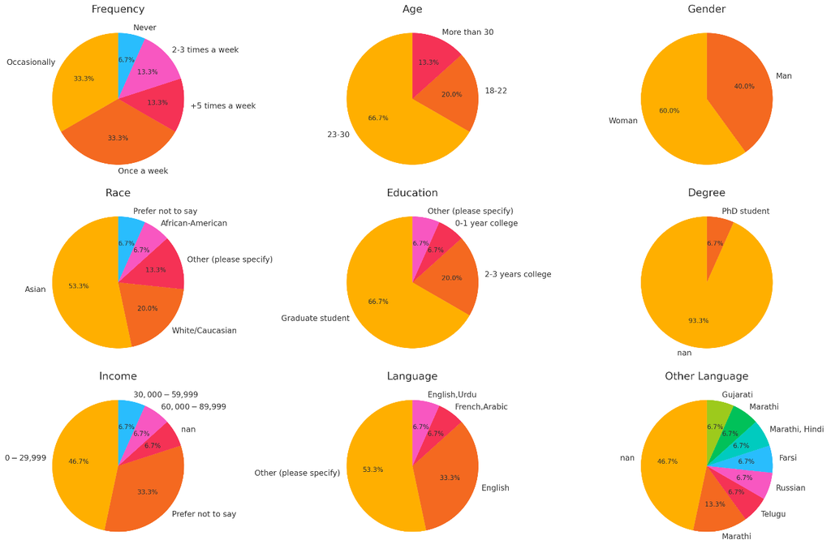

Figure 3: demographic and behavioral insights about the respondents

## Interviews

The key points captured from the interviews are listed below:

- There is only one fleet for ride services.
- Pickup locations:
- Galvin Library, from 7 to 9 p.m.
- Hermann Hall after 9 pm.
- The route passes 4 drop-off locations sequentially: Bridgeport, Lake Meadows, Prairie Shores, and Eden Commons and not in a first-come, first-served manner.
- The shift change for drivers is 9 pm for location and 10:45 for the driver. The ride services are not accessible from 11 pm to 12 am.
- ID is not checked, and just a form with name, address, and A number is asked.

The main identified challenges are in four categories: planning, operation, user experience, and communication.

Table 1 — the Challenges categorization

Category

Issues

Planning

- Inefficient Routing and Coverage Loop
- Driver Navigation and Route Knowledge Issues
- Limited‑Service Area Boundaries

Operation

- Limited Capacity and Long Wait Times
- Service Interruptions (Shift Changes and Breaks)
- Inflexible Scheduling & Data Blindness

User Experience

- Long Waits in Cold and Dark Conditions
- Inconvenient Pickup Location After 9 PM
- Chaotic Queue and Fairness Issues
- Reliability Concerns and Missed Rides
- Safety Concerns & Inconvenient Pickups

Communication

- Unclear Wait Time and Pickup Information
- Lack of Transparency in Operations
- No Tracking or Alert System (Technology Limitations)
- Inadequate Awareness and Promotion

## Equity index

The Equity Index framework is designed to assess how equitably a campus public safety ride (late-night shuttle) service is serving students. The framework covers multiple dimensions of service equity, with each dimension broken down into specific sub-indicators that can be checked for each student’s experience. Each sub-indicator is scored as 1 point if it applies to a student (0 if not). By tallying these points, we obtain an individual student’s equity score – higher scores indicate the student faces more barriers or shortcomings in the service. We can then average these scores across a group of students to gauge the overall equity of the service for that group. Table 2 is the framework table with each dimension, its definition, and the associated sub-indicators following Table 3, presenting the calculated Equity Index score for each interviewer and the final score.

Table 2 — the Equity Index framework

Dimension

Definition

Sub‑indicators

Access Equity

Whether a student can reliably receive  
a ride regardless of location or time.

- Live in underserved zone (e.g., Bridgeport past Halsted): 1 point
- Require walk >2 blocks to/from stop: 1 point
- Frequently ride during shift change: 1 point

Service Consistency

Variability in wait times and reliability

- Experienced missed rides: 1 point
- Waited >30 minutes more than twice: 1 point

Safety Exposure

Degree to which students are left  
walking in unsafe conditions.

- Walked alone at night due to no service: 1 point
- Dropped off far from home: 1 point

Information Access

How easily students can understand  
and use the system.

- Didn’t know service existed initially: 1 point
- Couldn’t get driver or clear directions when calling: 1 point
- Difficulty communicating pickup/drop‑off: 1 point

**Table 3: the Equity Index scores.**

[output not shown]

Table 4 — The strategies for enhancing DPS ride services

Category

Strategies

Planning

- Reservation sheet including A number, pickup time, department, and destination.
- Design an application based on route optimization to show the location of the fleet and waiting time.
- Training drivers to know the coverage districts.

Operation

- Increase the fleet from 8 pm to 10 pm. (1 for each neighborhood)
- Changing the shift change time to midnight.
- Assign a staff member or student worker at the main pickup location during busy hours to manage the queue and boarding order.

User experience

- Increasing the stations with the preference of students’ departments.
- Allocation of service with the priority of more passengers and the closest neighborhood.

Communication

- Announcement through banners on the fleet or boards.
- Equip drivers with a basic GPS device or pre-printed route maps of the service area.

### Critical takeaway:

One critical suggestion is to ensure that fleet allocation is in accordance with the areas of greatest demand and vulnerability, particularly during late-night and shift-change hours. Additionally, during periods of high volume, it is possible to reduce the average wait time and increase the efficiency of service coverage by prioritizing students in nearby neighborhoods.

These results provide the university administration with a practical guide to achieving more equitable public safety mobility. By implementing these strategies, we will not only improve operational efficiency but also guarantee that students who require transportation are provided with timely, safe, and dignified service. This will cultivate a campus environment that is more inclusive, academically supportive, and safer.

# Conclusion

Persistent inequities in access, reliability, and safety exist for students who depend on the university’s public safety ride service, particularly those who reside further from campus, travel during off-peak hours, or lack affordable transportation alternatives. Their academic engagement, well-being, and tranquility of mind are adversely affected by these disparities, which also increase their exposure to risk.

This challenge provides an opportunity to reimagine public safety mobility from an equity-centered perspective. The university can provide more ethical, inclusive, and student-centered services by prioritizing the needs of the most vulnerable students and grounding decisions in data.

This study developed a comprehensive Equity Index framework that quantifies transportation disadvantages based on a variety of factors, including residence location, time of use, commuting distance, safety vulnerability, and communication variables, using a data-driven qualitative study (interviewing) and equity-focused approach. The survey was for 15 students, followed by the challenges and key points derived from 5 interviews. In the Second Phase of this project, we can conduct a quantitative study by:

- Designing a detailed questionnaire to collect data from 100 DPS user or non-user students.
- Distributing the survey online and at public safety stations to capture a broad range of responses.
- Data analysis using statistical software
- Interpreting results
- Including route optimization to minimize the total travel time and waiting time and prepare the report to:
- Recommend strategies for equitable fleet distribution and scheduling during high-demand times.
- Implement a priority-based service system focusing on safety and equity.

# Appendix

To ensure the most effective and equitable use of IIT’s public safety ride services, we modeled and optimized **two demand scenarios**—representing **low and high student demand** relative to the vehicle capacity. Our objective was to **minimize total travel time and waiting time**, ensuring that the service remains efficient and responsive under varying usage levels.

**Assumptions**

- Fleet size: One vehicle
- Starting point: IIT Mies Campus
- Vehicle capacity: with 6-Person Vehicle Capacity
- Travel time:
- Bridgeport (15 minutes)
- East I-90 (10 minutes)
- Bridgeport to East I-90 (20 minutes)
- Objective: Minimize total travel time (vehicle + student wait/travel time)

🚗 Route Options

- Route A: Mies → Lake Meadows (LK) → Bridgeport (B)
- Route B: Mies → Bridgeport (B) → Lake Meadows (LK)

**Scenario A:**

2 LK, 1 B → 3 Students

- All fit in one trip.
- No waiting time.
- Route A (Mies → LK → B)
- 2 LK students: 10 min each = 20
- 1 B student: 10 (LK) + 20 = 30
- Total = 50 minutes
- Route B (Mies → B → LK)
- 1 B student: 15 min
- 2 LK students: 15 + 20 = 35 min each = 70
- Total = 85 minutes

✅ Best: Route A

**Scenario B**:

6 LK, 2 B → 8 Students

- Needs 2 trips (6-capacity limit).
- Strategy: prioritize majority (LK) in first trip to reduce overall wait.

- First trip: 6 LK students (fast, low wait)
- Second trip: 2 B students

# License

The author of this technical report, which was written as a deliverable for a SoReMo project, retains the copyright of the written material herein upon publication of this document in [SoReMo Reports](http://journals.library.iit.edu/index.php/Soremo/).

# References

https://cu-citizenaccess. n.d. “Org.” https://cu-citizenaccess.org.

https://transportation. n.d. “Upenn.” *Edu/*. https://transportation.upenn.edu/.

https://www. n.d.a. “Iit.” *Edu/Public-Safety/Safety-Awareness/Public-Safety-Escorts*. https://www.iit.edu/public-safety/safety-awareness/public-safety-escorts.

———. n.d.b. “Movoto.” *Com/Guide/Chicago-Il/Bronzeville-Chicago-Neighborhood/*. https://www.movoto.com/guide/chicago-il/bronzeville-chicago-neighborhood/.

http://www. n.d. “Orientation.” *Utexas*. http://www.orientation.utexas.edu.

(TIRF), Traffic Injury Research Foundation. 2017. “(2017).” *Safe Rides as an Alternative to Alcohol-Impaired Driving and Their Effects: A Literature Review*.

(TRB), Transportation Research Board. 2008. “(2008).” *Transit Systems in College and University Communities (TCRP Synthesis 78)*.

———. 2021. “(2021).” *Public University Campus Shuttle (Safety Program Case Study)*.

[^1]: Department of Civil, Architectural, and Environmental Engineering – Contact the author.